# R Notebook

```r
library(tidyverse)
library(tibble)
library(dplyr)
library(ggplot2)
library(dslabs)
library(scales)
library(QuantPsyc)
library(MASS)
library(data.table)
library(tidyr)
library(GGally)
```

1 glimpse(gapminder)

1.a

| country | year | gdp | previous_year_gdp |
| --- | --- | --- | --- |
| Albania | 1960 | NA | NA |
| Albania | 1961 | NA | NA |
| Albania | 1962 | NA | NA |
| Albania | 1963 | NA | NA |
| Albania | 1964 | NA | NA |
| Albania | 1965 | NA | NA |
| Albania | 1966 | NA | NA |
| Albania | 1967 | NA | NA |
| Albania | 1968 | NA | NA |
| Albania | 1969 | NA | NA |

[output cut: 990 more lines]

1.b

| continent | year | gdp | previous_year_gdp | change |
| --- | --- | --- | --- | --- |
| Africa | 1960 | 1.168719e+11 | NA | NA |
| Africa | 1961 | 1.202145e+11 | 1.168719e+11 | 0.0286004429 |
| Africa | 1962 | 1.247785e+11 | 1.202145e+11 | 0.0379656798 |
| Africa | 1963 | 1.355371e+11 | 1.247785e+11 | 0.0862215560 |
| Africa | 1964 | 1.433086e+11 | 1.355371e+11 | 0.0573381247 |
| Africa | 1965 | 1.524020e+11 | 1.433086e+11 | 0.0634534234 |
| Africa | 1966 | 1.551153e+11 | 1.524020e+11 | 0.0178038060 |
| Africa | 1967 | 1.607520e+11 | 1.551153e+11 | 0.0363382854 |
| Africa | 1968 | 1.684982e+11 | 1.607520e+11 | 0.0481877762 |
| Africa | 1969 | 1.805290e+11 | 1.684982e+11 | 0.0713997313 |

[output cut: 275 more lines]

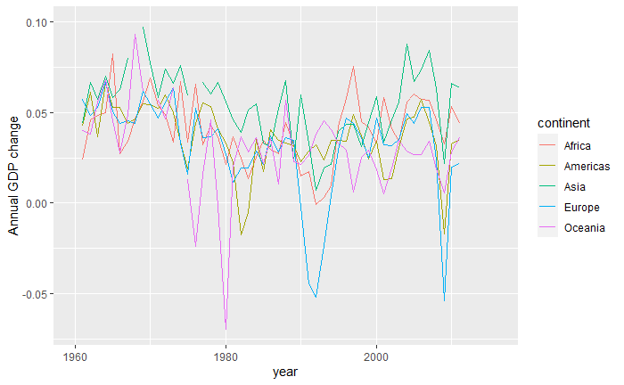

```r
gapminder%>%
  dplyr::select(continent, country,year,gdp)%>%
  group_by(country)%>%
  mutate(previous_year_gdp= lag(gdp),change=(gdp/previous_year_gdp-1))%>%
  group_by(continent, year) %>%
  summarise(avg_growth=mean(change,na.rm=TRUE))%>%
  ggplot(aes(x=year,y=avg_growth,group=continent,color=continent))+
  geom_line()+
  scale_y_continuous(name="Annual GDP change", limits=c(-0.07,0.1))
```

1.1.2

```r
gapminder %>%
  arrange(country)%>%
  dplyr::select(country, year,gdp,region)%>%
  mutate(py_gdp = lag(gdp))%>%
  mutate(growth=gdp/py_gdp-1)%>%
  group_by(region)%>%
  mutate(mgr=mean(growth,na.rm=TRUE))%>%
  mutate(diff = growth-mgr,na.rm=TRUE)%>%
  group_by(country)%>%
  summarise(sum_diff=sum(diff,na.rm=TRUE))%>%
  arrange(sum_diff)
```

| country | sum_diff |
| --- | --- |
| Congo, Dem. Rep. | -1.632885606 |
| Georgia | -1.555880832 |
| Central African Republic | -1.375308324 |
| Brunei | -1.350515835 |
| Japan | -1.227113873 |
| South Africa | -1.017931625 |
| Madagascar | -1.008277317 |
| Nicaragua | -0.972664663 |
| Philippines | -0.896994106 |
| Serbia | -0.887357370 |

[output cut: 175 more lines]

1.1.3

```r
gapminder %>%
  dplyr::select(country, year,gdp,region)%>%
  group_by(country)%>%
  mutate(py_gdp = lag(gdp))%>%
  mutate(growth=gdp/py_gdp-1,na.rm=TRUE)%>%
  group_by(region)%>%
  mutate(mgr=mean(growth,na.rm=TRUE))%>%
  mutate(bool_var = growth>mgr,na.rm=TRUE)%>%
  group_by(country)%>%
  summarise(summa=sum(bool_var,na.rm = TRUE))%>%
  arrange(desc(summa))
```

| country | summa |
| --- | --- |
| China | 41 |
| Botswana | 39 |
| Singapore | 39 |
| Chile | 37 |
| Dominican Republic | 36 |
| Colombia | 35 |
| Malaysia | 35 |
| Australia | 34 |
| Costa Rica | 34 |
| Latvia | 34 |

[output cut: 175 more lines]

1.2.1

1.2.1.1.a&b

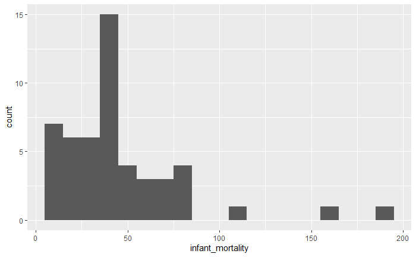

1.2.1.2.a

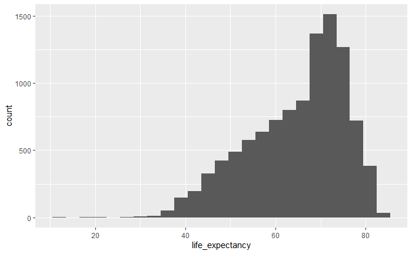

1.2.1.2.b

```r
gapminder %>%
  dplyr::select(country, year,life_expectancy)%>%
  group_by(country,year)%>%
  mutate(bool_var = life_expectancy<40,na.rm=TRUE)%>%
  group_by(country)%>%
  summarise(summa=sum(bool_var,na.rm = TRUE))%>%
  arrange(desc(summa))%>%
  mutate(n1=sum(summa,na.rm=TRUE))
```

| country | summa | n1 |
| --- | --- | --- |
| Mali | 18 | 198 |
| Niger | 17 | 198 |
| Guinea | 16 | 198 |
| Ethiopia | 12 | 198 |
| Senegal | 11 | 198 |
| Burkina Faso | 10 | 198 |
| Cambodia | 10 | 198 |
| Liberia | 10 | 198 |
| Yemen | 9 | 198 |
| Angola | 8 | 198 |

[output cut: 175 more lines]

```r
gapminder %>%
  dplyr::select(country, year,life_expectancy)%>%
  group_by(country,year)%>%
  mutate(bool_var = life_expectancy>80,na.rm=TRUE)%>%
  group_by(country)%>%
  summarise(summa=sum(bool_var,na.rm = TRUE))%>%
  arrange(desc(summa))%>%
  mutate(n1=sum(summa))
```

| country | summa | n1 |
| --- | --- | --- |
| Japan | 21 | 334 |
| Iceland | 18 | 334 |
| Hong Kong, China | 17 | 334 |
| Australia | 16 | 334 |
| Switzerland | 16 | 334 |
| Italy | 15 | 334 |
| Malta | 14 | 334 |
| Sweden | 14 | 334 |
| Canada | 13 | 334 |
| France | 13 | 334 |

[output cut: 175 more lines]

1.2.1.3

You probably want to use coord_cartesian instead of lims. Unexpected things can happen when you’re fiddling around with the limits on histograms, because a fair bit of fiddly transformations have to happen to get from your raw data to the actual histogram.

And then further oddities can happen because the bars may extend past the nominal data range (the xmin and xmax values), since the bar widths will generally encompass a little above and a little below your actual data at the high and low ends.

coord_cartesian will adjust the x limits after all this processing has happened, so it bypasses all these little quirks.

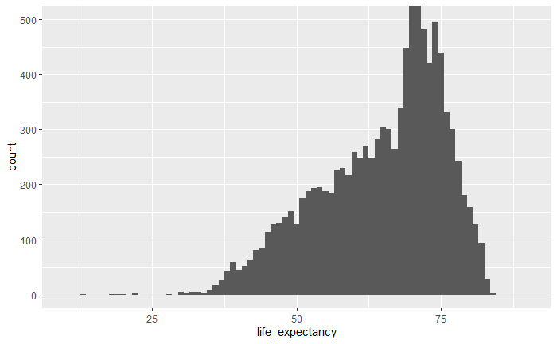

1.2.2.1

```
Ignoring unknown parameters: bins
```

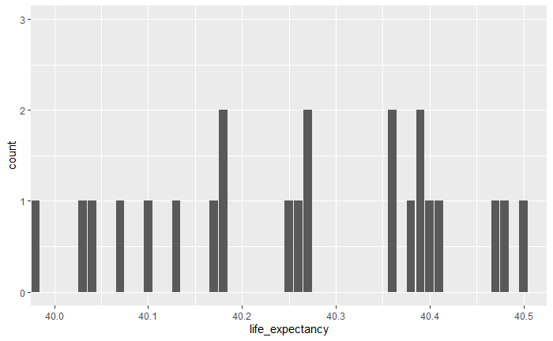

```r
  ggplot(gapminder, aes(x=life_expectancy,na.rm=FALSE))+
  geom_bar(bins=10)+
    coord_cartesian(
      xlim = c(40,40.5),
      ylim = c(0,3),
      expand = TRUE,
      default = FALSE,
      clip = "on"
)
```

1.2.2.2 if you sum over a column with na result is na if you take a mean over a column with ne the result is na

you can fix by using (,na.rm=TRUE)

2.1

```r
ggpairs(diamonds,progress=FALSE, binwidth=500)
```

[output not shown]

```
Extra arguments: "binwidth" are being ignored.  If these are meant to be aesthetics, submit them using the 'mapping' variable within ggpairs with ggplot2::aes or ggplot2::aes_string.
```

1.a It is the carat (the weight), the heavier the diamond, the more valuable it is. There is a strong correlation, 0,922. (x,y,and z) are also strongly correlated to carat as the are the dimensions of the diamond and the bigger they are the heavier it is)

1.b To show the relationship between price and cut we can look at the quantiles:

```r
diamonds %>%
  group_by(cut) %>%
  summarise(n=n(),
            mean= mean(price),
            median=median(price),
            Q1= quantile(price,0.25),
            Q3= quantile(price,0.75))
```

| cut | n | mean | median | Q1 | Q3 |
| --- | --- | --- | --- | --- | --- |
| Fair | 1610 | 4358.758 | 3282.0 | 2050.25 | 5205.50 |
| Good | 4906 | 3928.864 | 3050.5 | 1145.00 | 5028.00 |
| Very Good | 12082 | 3981.760 | 2648.0 | 912.00 | 5372.75 |
| Premium | 13791 | 4584.258 | 3185.0 | 1046.00 | 6296.00 |
| Ideal | 21551 | 3457.542 | 1810.0 | 878.00 | 4678.50 |

[output not shown]

[output cut: 990 more lines]

2.1.b

```r
cor(as.integer(diamonds$cut),diamonds$price)
```

```
[1] -0.05349066
```

2.1.c. fair = 1, Good = 2, Very good = 3, Premium = 4 and Ideal = 5 2.1.c shows the there is very l.ow negative correlation between the cut and the price of diamonds. This is because the weight/carat is far more important than the cut

```r
cor(diamonds$carat,diamonds$price)
```

```
[1] 0.9215913
```

This is best seen by noting that the correlation between carats and price is very high or posititve 0.92.